# Human Activity Recognition Predictions of Quality Movements

An analysis of covariates regarding proper and improper weight lifting activities

mjfii

July 21, 2015

# Executive Summary

Human activity recognition (HAR) has gained popularity over the years with the introduction of wearable devices, such as a Jawbone, producing large amounts of machine made data. It is very common for prediction algorithms to attempt to decipher what type of activity is being conducted, e.g. standing, walking, running, etc. However, in this analysis, we looked at a single activity carried out in 5 different ways, 1 correct way, and 4 incorrect ways. In order to do so, we utilized a study and underlying data set on this topic, which can be found here: (http://groupware.les.inf.puc-rio.br/har). The process for collecting the data, can be summed up with the below quote.

*“Six young health participants were asked to perform one set of 10 repetitions of the unilateral dumbbell biceps curl in five different **fashions**: exactly according to the specification (Class A), throwing the elbows to the front (Class B), lifting the dumbbell only halfway (Class C), lowering the dumbbell only halfway (Class D) and throwing the hips to the front (Class E).”* <sup>[1]</sup>

These ‘fashions’ are the subject of the prediction algorithm; more simply put, based on the movements from the utilized accelerometers used in the study, in what way were the participants executing the bicep curls.

The final model uses principle component analysis (PCA) and a random forest algorithm to predict each outcome. Furthermore, it has a very high out-of-sample accuracy of 96.2%.

# Initialization

In order to conduct this machine learning methodology, we need to load the `caret`, `rattle`, and the `randomForest` packages - note they have been previously installed with all their dependencies. Additionally, there are 2 external R scripts that we will utilize to work with physical files. More information on these can be found in the Appendix.

```r
suppressMessages(library(caret))
suppressMessages(library(rattle))
suppressMessages(library(randomForest))

source('download data set.R')
source('submit files.R')
```

# Source Data

The source data used in this publication can be found here: [training](https://d396qusza40orc.cloudfront.net/predmachlearn/pml-training.csv) and [testing](https://d396qusza40orc.cloudfront.net/predmachlearn/pml-testing.csv)

# Getting and Cleaning Data

```r
training.set <- read.csv('source data/training set.csv',na.strings=c('NA','DIV/0!',''))[,7:160]
testing.set <- read.csv('source data/testing set.csv',na.strings=c('NA','DIV/0!',''))[,7:160]
```

In order to conduct cross validation in future stages, we need to break down the training set further in to two working sets, a functional training set and a set in which we will test our model fitting - we will call it the probe set. 75% will be in the former, and 25% will be in the latter.

```r
set.seed(19801104)
inTrain = createDataPartition(training.set$classe,p=0.75,list = FALSE)
```

Once we set the partition and apply it to each set, you can see the dimensional breakdown of the observations and variables below.

```r
probe.set = training.set [-inTrain, ]
dim(probe.set)
```

```
## [1] 4904  154
```

```r
training.set = training.set [inTrain, ]
dim(training.set)
```

```
## [1] 14718   154
```

After a cursory review of the training set, many attributes are missing values. Since this is does not work well with prediction models, we have the option of trying to impute the data, or simply removing the variables in their entirety. Since there are over 150 variables in the set, we will start by removing them. When we do this we are left with just 53 variables to work with during the modeling process.

```r
complete.vector <- apply(!is.na(training.set),2,sum) >= nrow(training.set)
training.set <- training.set[,complete.vector]
probe.set <- probe.set[,complete.vector]
testing.set <- testing.set[,complete.vector]
```

Two other cleaning exercises that we conducted were removing variables with little to no variance across the set, using the `nearZeroVar()` function, and pairing down the variables that shared a very high (95%+) correlation. It is important to note, that neither of these methods changed the training set in any significant way.

# Exploratory Analysis

We can take a quick look at the data using the common `str` function. We can see there are integer and double precision numbers in the set. There is also three-dimensional data representations, i.e. x, y, and z axis data, with both positive and negative values.

```r
str(training.set, list.len=20)
```

```
## 'data.frame':    14718 obs. of  54 variables:
##  $ num_window          : int  11 11 11 12 12 12 12 12 12 12 ...
##  $ roll_belt           : num  1.41 1.41 1.42 1.48 1.48 1.45 1.42 1.42 1.43 1.45 ...
##  $ pitch_belt          : num  8.07 8.07 8.07 8.05 8.07 8.06 8.09 8.13 8.16 8.17 ...
##  $ yaw_belt            : num  -94.4 -94.4 -94.4 -94.4 -94.4 -94.4 -94.4 -94.4 -94.4 -94.4 ...
##  $ total_accel_belt    : int  3 3 3 3 3 3 3 3 3 3 ...
##  $ gyros_belt_x        : num  0 0.02 0 0.02 0.02 0.02 0.02 0.02 0.02 0.03 ...
##  $ gyros_belt_y        : num  0 0 0 0 0.02 0 0 0 0 0 ...
##  $ gyros_belt_z        : num  -0.02 -0.02 -0.02 -0.03 -0.02 -0.02 -0.02 -0.02 -0.02 0 ...
##  $ accel_belt_x        : int  -21 -22 -20 -22 -21 -21 -22 -22 -20 -21 ...
##  $ accel_belt_y        : int  4 4 5 3 2 4 3 4 2 4 ...
##  $ accel_belt_z        : int  22 22 23 21 24 21 21 21 24 22 ...
##  $ magnet_belt_x       : int  -3 -7 -2 -6 -6 0 -4 -2 1 -3 ...
##  $ magnet_belt_y       : int  599 608 600 604 600 603 599 603 602 609 ...
##  $ magnet_belt_z       : int  -313 -311 -305 -310 -302 -312 -311 -313 -312 -308 ...
##  $ roll_arm            : num  -128 -128 -128 -128 -128 -128 -128 -128 -128 -128 ...
##  $ pitch_arm           : num  22.5 22.5 22.5 22.1 22.1 22 21.9 21.8 21.7 21.6 ...
##  $ yaw_arm             : num  -161 -161 -161 -161 -161 -161 -161 -161 -161 -161 ...
##  $ total_accel_arm     : int  34 34 34 34 34 34 34 34 34 34 ...
##  $ gyros_arm_x         : num  0 0.02 0.02 0.02 0 0.02 0 0.02 0.02 0.02 ...
##  $ gyros_arm_y         : num  0 -0.02 -0.02 -0.03 -0.03 -0.03 -0.03 -0.02 -0.03 -0.03 ...
##   [list output truncated]
```

To take a quick look at the importance of certain variables, we can fit a model using the `rpart` method and we see the roll_belt attribute seems to play a large part in classifying the movement. Other variables and their thresholds can be seen in the breakdown below.

```r
ex.fit <- train(classe ~ .,method='rpart',data=training.set)
```

```r
ex.fit$finalModel
```

```
## n= 14718
##
## node), split, n, loss, yval, (yprob)
##       * denotes terminal node
##
##  1) root 14718 10533 A (0.28 0.19 0.17 0.16 0.18)
##    2) roll_belt< 130.5 13475  9300 A (0.31 0.21 0.19 0.18 0.11)
##      4) pitch_forearm< -34.15 1165     7 A (0.99 0.006 0 0 0) *
##      5) pitch_forearm>=-34.15 12310  9293 A (0.25 0.23 0.21 0.2 0.12)
##       10) magnet_dumbbell_y< 438.5 10346  7391 A (0.29 0.18 0.24 0.19 0.11)
##         20) roll_forearm< 122.5 6433  3800 A (0.41 0.18 0.18 0.17 0.06) *
##         21) roll_forearm>=122.5 3913  2615 C (0.082 0.18 0.33 0.23 0.18) *
##       11) magnet_dumbbell_y>=438.5 1964   984 B (0.032 0.5 0.047 0.23 0.19) *
##    3) roll_belt>=130.5 1243    10 E (0.008 0 0 0 0.99) *
```

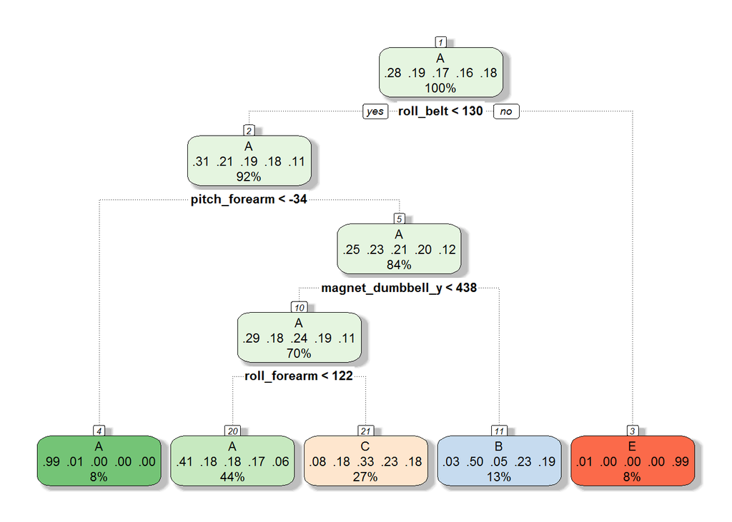

```r
fancyRpartPlot(ex.fit$finalModel, main='', sub='')
```

# Principle Component Analysis

In order to trim down the variables to more manageable number for a prediction algorithm, we will conduct a Principle Component Analysis to isolate components, or usable features, which will capture 80% of the variance of the training set.

```r
pc <- preProcess(training.set[,-54],method='pca',thres=0.80)
```

The below `rotation` code is not evaluated at this point in the publication, but it can be viewed in the Appendix. Regardless, the Principle Component Analysis that was executed trimmed the relevant features down to 13 from 53.

```r
pc$rotation
```

At this point we are content with 13 solid variables to use for predicting the `$classe` HAR weight lifting movement. Since we we conducted the PCA on the training set, we now need to apply the same methods to the probe and testing sets, as seen below.

```r
training.pc <- predict(pc,training.set[,-54])
probe.pc <- predict(pc,probe.set[,-54])
testing.pc <- predict(pc,testing.set[,-54])
```

# Modeling

```r
tc <- trainControl(method = 'cv', number = 3)
fit <- train(training.set$classe ~ ., method='rf', data=training.pc, allowParallel=TRUE, prox=TRUE, tcControl=tc)
```

This process took a bit of time, 15 plus minutes to build the fitting. It was processed on a 64 bit machine with 16 GB of RAM and utilizing R version 3.2.1 (2015-06-18).

# Prediction and Accuracy

Finally, we get to predict based on our fitting. We can use the `predict` function with the probe set as an argument to conduct this process.

```r
prediction <- predict(fit, newdata=probe.pc)
```

Now, we can compare the actual `classe` values of the probe set to those that we predicted. As seen below the model is very effective with an accuracy of 96% and a Kappa of 0.95. The algorithm seemed to have the most difficulty try to decipher between lowering the barbell half way (D), versus lifting the barbell halfway (C). Irrespective, the out of sample error rate is approximately 4%. A confusion matrix is printed below with a complete breakdown of the prediction.

```r
confusionMatrix(prediction,probe.set$classe)
```

```
## Confusion Matrix and Statistics
##
##           Reference
## Prediction    A    B    C    D    E
##          A 1364   23    2    8    2
##          B    8  889    7    1    9
##          C   12   30  829   32   11
##          D   11    4   17  761    6
##          E    0    3    0    2  873
##
## Overall Statistics
##
##                Accuracy : 0.9617
##                  95% CI : (0.9559, 0.9669)
##     No Information Rate : 0.2845
##     P-Value [Acc > NIR] : < 2.2e-16
##
##                   Kappa : 0.9515
##  Mcnemar's Test P-Value : 5.85e-08
##
## Statistics by Class:
##
##                      Class: A Class: B Class: C Class: D Class: E
## Sensitivity            0.9778   0.9368   0.9696   0.9465   0.9689
## Specificity            0.9900   0.9937   0.9790   0.9907   0.9988
## Pos Pred Value         0.9750   0.9726   0.9070   0.9524   0.9943
## Neg Pred Value         0.9912   0.9850   0.9935   0.9895   0.9930
## Prevalence             0.2845   0.1935   0.1743   0.1639   0.1837
## Detection Rate         0.2781   0.1813   0.1690   0.1552   0.1780
## Detection Prevalence   0.2853   0.1864   0.1864   0.1629   0.1790
## Balanced Accuracy      0.9839   0.9652   0.9743   0.9686   0.9838
```

# Conclusion and Submission

Since the model has been defined with such a high degree of accuracy, we can compare it to the testing set. When we do so, the accuracy remains sufficient as we predicted each of the 20 testing observations correctly.

```r
submission <- predict(fit, newdata=testing.pc)
submission
```

```
##  [1] B A B A A E D B A A B C B A E E A B B B
## Levels: A B C D E
```

```r
write.files(submission)
```

# References

[1] Velloso, E.; Bulling, A.; Gellersen, H.; Ugulino, W.; Fuks, H. Qualitative Activity Recognition of Weight Lifting Exercises. Proceedings of 4th International Conference in Cooperation with SIGCHI (Augmented Human ’13) . Stuttgart, Germany: ACM SIGCHI, 2013.

[Read more here…](http://groupware.les.inf.puc-rio.br/public/papers/2013.Velloso.QAR-WLE.pdf)

# Appendix

The `write.files` function used for the submission is below.

```r
write.files
```

```
## function (x)
## {
##     if (!file.exists("submission")) {
##         dir.create("submission")
##     }
##     n = length(x)
##     for (i in 1:n) {
##         filename = paste0("submission/problem_id_", i, ".txt")
##         write.table(x[i], file = filename, quote = FALSE, row.names = FALSE,
##             col.names = FALSE)
##     }
## }
```

The `download.data` function gets all the working files and places them in the appropriate files for future use.

```r
download.data
```

```
## function ()
## {
##     if (!file.exists("source data")) {
##         dir.create("source data")
##     }
##     files.to.download <- c("https://d396qusza40orc.cloudfront.net/predmachlearn/pml-training.csv",
##         "https://d396qusza40orc.cloudfront.net/predmachlearn/pml-testing.csv")
##     downloaded.names <- c("source data/training set.csv", "source data/testing set.csv")
##     if (!file.exists(downloaded.names[1])) {
##         download.file(files.to.download[1], downloaded.names[1])
##     }
##     if (!file.exists(downloaded.names[2])) {
##         download.file(files.to.download[2], downloaded.names[2])
##     }
## }
```

The prediction `rotation` can be found below with respect to the PCA.

```r
pc$rotation
```

```
##                               PC1          PC2          PC3           PC4
## num_window           -0.001515166  0.086317921 -0.036561264  0.0049134648
## roll_belt             0.309932532  0.123942248  0.073588096  0.0300701270
## pitch_belt            0.018809255 -0.290227640  0.067703633  0.0390786792
## yaw_belt              0.205504620  0.247600035  0.023369826  0.0012374190
## total_accel_belt      0.306137622  0.104602974  0.094907773  0.0344491112
## gyros_belt_x         -0.090213224  0.194894626 -0.194757477 -0.0506853014
## gyros_belt_y          0.108422834  0.207266083 -0.081822431 -0.0326313087
## gyros_belt_z         -0.180011701  0.050109439 -0.105636514 -0.0434435507
## accel_belt_x         -0.003821971  0.292576354 -0.084911708 -0.0420619917
## accel_belt_y          0.317527084  0.033564433  0.100341963  0.0421890276
## accel_belt_z         -0.318458626 -0.099498416 -0.069094989 -0.0301119034
## magnet_belt_x         0.021666686  0.287205834 -0.041668093 -0.0265398846
## magnet_belt_y        -0.114942862  0.092142106  0.077087803  0.0174579563
## magnet_belt_z        -0.058278819  0.121963825  0.064728995  0.0161372265
## roll_arm             -0.064470385 -0.178173624 -0.061913217 -0.0338815517
## pitch_arm            -0.035095795  0.067724393  0.227982009  0.0750860013
## yaw_arm              -0.051202735 -0.115138016 -0.006113475 -0.0137723350
## total_accel_arm      -0.114617079 -0.035185401 -0.056671778 -0.0006619857
## gyros_arm_x           0.012543019  0.050455877 -0.004717400 -0.0026798463
## gyros_arm_y          -0.077011776 -0.078852675  0.009125065  0.0021565267
## gyros_arm_z           0.161428947  0.181301810 -0.069976101 -0.0131299725
## accel_arm_x           0.158786776 -0.111097885 -0.170344753 -0.0599335586
## accel_arm_y          -0.269738536 -0.120631233  0.130518299  0.0245398851
## accel_arm_z           0.127961638 -0.007458285  0.271389922  0.0731778569
## magnet_arm_x          0.090117564 -0.011571803 -0.262971370 -0.0884078615
## magnet_arm_y         -0.063424057  0.026635045  0.364951986  0.1060749172
## magnet_arm_z         -0.030299313  0.026543964  0.303710637  0.0898413362
## roll_dumbbell        -0.083524723  0.128537990 -0.054020436 -0.0286185710
## pitch_dumbbell        0.106499480 -0.151971277 -0.091862729 -0.0412797396
## yaw_dumbbell          0.119670160 -0.267409179 -0.006868518  0.0128361416
## total_accel_dumbbell -0.165605819  0.149702695  0.120853616  0.0444714458
## gyros_dumbbell_x      0.006562720 -0.010302427  0.145820838 -0.4385066042
## gyros_dumbbell_y     -0.001579318  0.040753116 -0.103248304  0.3567188293
## gyros_dumbbell_z     -0.003407479  0.005450333 -0.129445937  0.4409974201
## accel_dumbbell_x      0.167226818 -0.142816697 -0.130226047 -0.0593193612
## accel_dumbbell_y     -0.178461141  0.183060863  0.005869431 -0.0031800766
## accel_dumbbell_z      0.150221546 -0.249543441 -0.071988020  0.0036454690
## magnet_dumbbell_x     0.164472522 -0.199028870  0.142418476  0.0425225454
## magnet_dumbbell_y    -0.142043876  0.174690956 -0.203350765 -0.0557548340
```

[output cut: 161 more lines]

```
## magnet_dumbbell_y    -0.019034726
## magnet_dumbbell_z     0.074173441
## roll_forearm          0.145467023
## pitch_forearm         0.127475805
## yaw_forearm           0.101967211
## total_accel_forearm  -0.253534411
## gyros_forearm_x       0.002256876
## gyros_forearm_y       0.053324367
## gyros_forearm_z       0.026745996
## accel_forearm_x      -0.079963119
## accel_forearm_y      -0.022462339
## accel_forearm_z       0.119998166
## magnet_forearm_x     -0.041083258
## magnet_forearm_y     -0.044545968
## magnet_forearm_z      0.014792678
```

The summary of the tidy training set is view with the `summary` function.

```r
summary(training.set)
```

```
##    num_window    roll_belt        pitch_belt          yaw_belt
##  Min.   :  1   Min.   :-28.90   Min.   :-55.8000   Min.   :-180.00
##  1st Qu.:222   1st Qu.:  1.10   1st Qu.:  1.7900   1st Qu.: -88.30
##  Median :424   Median :114.00   Median :  5.2900   Median : -12.60
##  Mean   :431   Mean   : 64.45   Mean   :  0.3205   Mean   : -11.14
##  3rd Qu.:645   3rd Qu.:123.00   3rd Qu.: 15.0000   3rd Qu.:  13.07
##  Max.   :864   Max.   :162.00   Max.   : 60.3000   Max.   : 179.00
##  total_accel_belt  gyros_belt_x       gyros_belt_y       gyros_belt_z
##  Min.   : 0.00    Min.   :-1.04000   Min.   :-0.64000   Min.   :-1.4600
##  1st Qu.: 3.00    1st Qu.:-0.03000   1st Qu.: 0.00000   1st Qu.:-0.2000
##  Median :17.00    Median : 0.03000   Median : 0.02000   Median :-0.1000
##  Mean   :11.31    Mean   :-0.00506   Mean   : 0.03962   Mean   :-0.1308
##  3rd Qu.:18.00    3rd Qu.: 0.11000   3rd Qu.: 0.11000   3rd Qu.:-0.0200
##  Max.   :29.00    Max.   : 2.22000   Max.   : 0.64000   Max.   : 1.6100
##   accel_belt_x       accel_belt_y     accel_belt_z     magnet_belt_x
##  Min.   :-120.000   Min.   :-69.00   Min.   :-275.00   Min.   :-49.00
##  1st Qu.: -21.000   1st Qu.:  3.00   1st Qu.:-162.00   1st Qu.:  9.00
##  Median : -15.000   Median : 35.00   Median :-152.00   Median : 34.00
##  Mean   :  -5.649   Mean   : 30.21   Mean   : -72.67   Mean   : 55.43
##  3rd Qu.:  -5.000   3rd Qu.: 61.00   3rd Qu.:  27.00   3rd Qu.: 59.00
##  Max.   :  83.000   Max.   :164.00   Max.   : 105.00   Max.   :485.00
##  magnet_belt_y   magnet_belt_z       roll_arm        pitch_arm
##  Min.   :359.0   Min.   :-623.0   Min.   :-180.0   Min.   :-88.800
##  1st Qu.:581.0   1st Qu.:-375.0   1st Qu.: -32.3   1st Qu.:-25.800
##  Median :601.0   Median :-320.0   Median :   0.0   Median :  0.000
##  Mean   :593.7   Mean   :-345.4   Mean   :  17.7   Mean   : -4.673
##  3rd Qu.:610.0   3rd Qu.:-306.0   3rd Qu.:  77.2   3rd Qu.: 11.100
##  Max.   :673.0   Max.   : 293.0   Max.   : 180.0   Max.   : 88.500
##     yaw_arm         total_accel_arm  gyros_arm_x        gyros_arm_y
##  Min.   :-180.000   Min.   : 1.00   Min.   :-6.37000   Min.   :-3.3700
##  1st Qu.: -43.000   1st Qu.:17.00   1st Qu.:-1.35000   1st Qu.:-0.8000
##  Median :   0.000   Median :27.00   Median : 0.08000   Median :-0.2400
##  Mean   :  -0.883   Mean   :25.42   Mean   : 0.04471   Mean   :-0.2585
##  3rd Qu.:  45.600   3rd Qu.:33.00   3rd Qu.: 1.59000   3rd Qu.: 0.1400
##  Max.   : 180.000   Max.   :66.00   Max.   : 4.87000   Max.   : 2.8400
##   gyros_arm_z       accel_arm_x       accel_arm_y       accel_arm_z
##  Min.   :-2.3300   Min.   :-371.00   Min.   :-318.00   Min.   :-636.00
##  1st Qu.:-0.0700   1st Qu.:-240.00   1st Qu.: -55.00   1st Qu.:-144.00
##  Median : 0.2300   Median : -40.00   Median :  14.00   Median : -47.00
##  Mean   : 0.2703   Mean   : -59.12   Mean   :  32.12   Mean   : -71.45
```

[output cut: 50 more lines]

```
##  Max.   :311.00000   Max.   :231.0000   Max.   : 477.00   Max.   : 923.0
##  accel_forearm_z   magnet_forearm_x  magnet_forearm_y magnet_forearm_z
##  Min.   :-446.00   Min.   :-1280.0   Min.   :-896.0   Min.   :-973.0
##  1st Qu.:-182.00   1st Qu.: -616.0   1st Qu.:  -5.0   1st Qu.: 183.0
##  Median : -39.00   Median : -376.0   Median : 587.0   Median : 509.0
##  Mean   : -55.65   Mean   : -312.8   Mean   : 376.5   Mean   : 392.7
##  3rd Qu.:  26.00   3rd Qu.:  -77.0   3rd Qu.: 736.0   3rd Qu.: 653.0
##  Max.   : 291.00   Max.   :  672.0   Max.   :1480.0   Max.   :1090.0
##  classe
##  A:4185
##  B:2848
##  C:2567
##  D:2412
##  E:2706
##
```